# Projet final

Eunice SITTI-MAWUBEJRO

2025-07-02

Une tourbière est une zone humide colonisée par la végétation et où s’accumule progressivement la tourbe (matériau organique issue de la décomposition incomplète de végétaux dans un milieu saturé en eau et pauvre en oxygène.). Bien qu’elles ne couvrent que 3% des terres émergées, les tourbières peuvent stocker entre 30 à 33% du carbone mondial; elles jouent donc un rôle important dans les enjeux climatiques. En plus de celà, les tourbières ont un impact important sur le cycle de l’eau, en prévenant par exemple des innondations. Malgré leur importance, les tourbières restent peu connues, mal comprises et font l’objet d’exploitation.

Dans notre projet, nous travaillons sur la tourbière de La Guette à partir de données collectées dans le cadre du projet Junon, qui vise à développer un jumeau numérique de cet écosystème. Ce jumeau numérique permet de simuler le fonctionnement écologique de la tourbière à partir d’un ensemble de données environnementales, incluant notamment les flux de $CO_2$, de $CH_4$, l’évapotranspiration, la température du sol ou encore l’humidité.

Notre objectif est de mener une analyse multidimensionnelle de ces données afin de mieux comprendre le fonctionnement de la tourbière. Pour ce faire, nous allons:

-Nettoyer les données, en identifiant les valeurs manquantes et les valeurs aberrantes, puis en les imputant à l’aide de méthodes appropriées.\

-Réaliser une Analyse en Composantes Principales (ACP) en mettant en supplémentaires les variables $CO_2$, de $CH_4$, afin d’interpréter les grandes structures de variation et de repérer les variables les plus influentes dans le système étudié.\

-Analyser les composantes principales comme des séries temporelles, en étudiant leurs tendances, saisonnalités et anomalies à l’aide des outils vus en cours.\

Enfin, nous chercherons à modéliser les séries chronologiques de $CO_2$ et $CH_4$₄, en particulier à travers des régressions sur les composantes principales, pour mieux comprendre leur dynamique et leur sensibilité aux autres variables environnementales.

### Chargement des bibliothèques

Nous commençons par charger nos library.

```r
# chargement des biblithèques
library(tseries) # pour étudier les séries tempo
library(dygraphs) # pour des graphiques interactifs
library(VIM)
library(corrplot) #pour afficher les corrélation
library(missMDA) #pour faire des imputation
library(xts)
library(ggplot2) #pour des graphiques
library(ade4) #pour faire l'acp
library(devtools)
library(factoextra)
library(forecast)
library(TSA)
library(imputeTS)
```

### Chargement des données et exploration

```r
#chargement des données
data1 = read.table("dataprojet1.txt",header = TRUE)

# résumé pour explorer
summary(data1)
```

```
##      Date                ETR               FCO2               FCH4
##  Length:1807        Min.   :-0.0228   Min.   :-14.6950   Min.   :-0.1244
##  Class :character   1st Qu.: 0.0063   1st Qu.: -3.1503   1st Qu.:-0.0296
##  Mode  :character   Median : 0.0307   Median :  0.2196   Median :-0.0107
##                     Mean   : 0.0665   Mean   : -1.1414   Mean   :-0.0180
##                     3rd Qu.: 0.0844   3rd Qu.:  1.0914   3rd Qu.:-0.0025
##                     Max.   : 0.6321   Max.   : 11.3887   Max.   : 0.0568
##                     NA's   :517       NA's   :621        NA's   :909
##       Heat              LHeat           SoilHeatd2      lgt.bm1_G_1_1_2
##  Min.   :-55.7861   Min.   :-46.908   Min.   :-19.250   Min.   :-32.452
##  1st Qu.:  0.8898   1st Qu.:  8.694   1st Qu.: -4.434   1st Qu.: -5.077
##  Median : 30.6034   Median : 28.767   Median : -1.304   Median : -1.925
##  Mean   : 50.2736   Mean   : 55.600   Mean   : -1.385   Mean   : -1.724
##  3rd Qu.: 92.6605   3rd Qu.: 78.419   3rd Qu.:  1.686   3rd Qu.:  1.429
##  Max.   :335.5177   Max.   :342.681   Max.   : 14.569   Max.   : 16.272
##  NA's   :618        NA's   :636       NA's   :13        NA's   :13
##  lgt.bm1_P_1_1_1  lgt.bm1_PA_1_1_1 lgt.bm1_PPFD_IN_1_1_1 lgt.bm1_RH_1_1_1
##  Min.   : 0.000   Min.   : 961.5   Min.   :  0.0         Min.   :44.12
##  1st Qu.: 0.000   1st Qu.: 994.9   1st Qu.:123.1         1st Qu.:76.13
##  Median : 0.200   Median : 999.7   Median :263.2         Median :84.31
##  Mean   : 1.853   Mean   : 999.1   Mean   :272.5         Mean   :82.96
##  3rd Qu.: 1.800   3rd Qu.:1004.0   3rd Qu.:410.6         3rd Qu.:90.96
##  Max.   :43.800   Max.   :1023.2   Max.   :635.5         Max.   :99.98
##  NA's   :13       NA's   :13       NA's   :13            NA's   :105
##  lgt.bm1_SWC_1_1_1 lgt.bm1_SWC_1_1_2 lgt.bm1_SWC_1_2_1 lgt.bm1_SWC_1_3_1
##  Min.   : 0.00     Min.   :29.92     Min.   : 0.00     Min.   :64.77
##  1st Qu.:34.19     1st Qu.:69.38     1st Qu.:70.14     1st Qu.:73.57
##  Median :40.90     Median :72.65     Median :76.53     Median :73.87
##  Mean   :37.45     Mean   :70.40     Mean   :69.63     Mean   :73.64
##  3rd Qu.:47.11     3rd Qu.:74.55     3rd Qu.:77.76     3rd Qu.:74.32
##  Max.   :64.09     Max.   :77.05     Max.   :79.43     Max.   :74.71
##  NA's   :13        NA's   :13        NA's   :13        NA's   :13
##        TA         lgt.bm1_TS_1_1_1 lgt.bm1_TS_1_1_2 lgt.bm1_TS_1_2_1
##  Min.   :-6.430   Min.   :-2.356   Min.   :-1.184   Min.   :-0.7548
##  1st Qu.: 6.497   1st Qu.: 5.907   1st Qu.: 6.364   1st Qu.: 6.1722
##  Median :10.739   Median : 9.849   Median :10.627   Median :10.0357
##  Mean   :10.744   Mean   :10.085   Mean   :10.874   Mean   :10.3339
##  3rd Qu.:15.320   3rd Qu.:14.647   3rd Qu.:15.793   3rd Qu.:14.8772
##  Max.   :26.062   Max.   :21.754   Max.   :22.762   Max.   :21.5054
##  NA's   :30       NA's   :13       NA's   :13       NA's   :13
```

[output cut: 73 more lines]

```
##  Min.   : 0.0306   Min.   : 1.250   Min.   : 0.5698   Min.   : 2.521
##  1st Qu.: 5.7602   1st Qu.: 7.241   1st Qu.: 5.8196   1st Qu.: 7.139
##  Median : 9.3661   Median :10.772   Median : 9.0963   Median : 9.833
##  Mean   : 9.8738   Mean   :11.360   Mean   : 9.6900   Mean   :10.519
##  3rd Qu.:14.1357   3rd Qu.:15.765   3rd Qu.:13.6670   3rd Qu.:13.981
##  Max.   :20.8620   Max.   :22.662   Max.   :19.3394   Max.   :18.658
##  NA's   :359       NA's   :359      NA's   :359       NA's   :359
##  lgt.bm2_TS_2_6_1  lgt.bm2_WTD
##  Min.   : 4.533   Min.   :-0.5638
##  1st Qu.: 7.804   1st Qu.:-0.0868
##  Median :10.053   Median :-0.0394
##  Mean   :10.567   Mean   :-0.0783
##  3rd Qu.:13.448   3rd Qu.:-0.0318
##  Max.   :16.892   Max.   : 0.2856
##  NA's   :359      NA's   :359
```

```r
dim(data1)
```

```
## [1] 1807   60
```

la première colonne Date est affichée comme chaine de caractère. Il faudra réadapter le format pour que ce soit vu comme une date.

```r
#réadapter le format de la date
date=as.Date(data1[,1])  #formatage de la date

#refaire un dataframe avec le bon format de date et les variables
donnees = data.frame(date,data1[,-1])
summary(donnees)
```

```
##       date                 ETR               FCO2               FCH4
##  Min.   :2017-01-19   Min.   :-0.0228   Min.   :-14.6950   Min.   :-0.1244
##  1st Qu.:2018-04-15   1st Qu.: 0.0063   1st Qu.: -3.1503   1st Qu.:-0.0296
##  Median :2019-07-11   Median : 0.0307   Median :  0.2196   Median :-0.0107
##  Mean   :2019-07-10   Mean   : 0.0665   Mean   : -1.1414   Mean   :-0.0180
##  3rd Qu.:2020-10-04   3rd Qu.: 0.0844   3rd Qu.:  1.0914   3rd Qu.:-0.0025
##  Max.   :2021-12-30   Max.   : 0.6321   Max.   : 11.3887   Max.   : 0.0568
##                       NA's   :517       NA's   :621        NA's   :909
##       Heat              LHeat           SoilHeatd2      lgt.bm1_G_1_1_2
##  Min.   :-55.7861   Min.   :-46.908   Min.   :-19.250   Min.   :-32.452
##  1st Qu.:  0.8898   1st Qu.:  8.694   1st Qu.: -4.434   1st Qu.: -5.077
##  Median : 30.6034   Median : 28.767   Median : -1.304   Median : -1.925
##  Mean   : 50.2736   Mean   : 55.600   Mean   : -1.385   Mean   : -1.724
##  3rd Qu.: 92.6605   3rd Qu.: 78.419   3rd Qu.:  1.686   3rd Qu.:  1.429
##  Max.   :335.5177   Max.   :342.681   Max.   : 14.569   Max.   : 16.272
##  NA's   :618        NA's   :636       NA's   :13        NA's   :13
##  lgt.bm1_P_1_1_1  lgt.bm1_PA_1_1_1 lgt.bm1_PPFD_IN_1_1_1 lgt.bm1_RH_1_1_1
##  Min.   : 0.000   Min.   : 961.5   Min.   :  0.0         Min.   :44.12
##  1st Qu.: 0.000   1st Qu.: 994.9   1st Qu.:123.1         1st Qu.:76.13
##  Median : 0.200   Median : 999.7   Median :263.2         Median :84.31
##  Mean   : 1.853   Mean   : 999.1   Mean   :272.5         Mean   :82.96
##  3rd Qu.: 1.800   3rd Qu.:1004.0   3rd Qu.:410.6         3rd Qu.:90.96
##  Max.   :43.800   Max.   :1023.2   Max.   :635.5         Max.   :99.98
##  NA's   :13       NA's   :13       NA's   :13            NA's   :105
##  lgt.bm1_SWC_1_1_1 lgt.bm1_SWC_1_1_2 lgt.bm1_SWC_1_2_1 lgt.bm1_SWC_1_3_1
##  Min.   : 0.00     Min.   :29.92     Min.   : 0.00     Min.   :64.77
##  1st Qu.:34.19     1st Qu.:69.38     1st Qu.:70.14     1st Qu.:73.57
##  Median :40.90     Median :72.65     Median :76.53     Median :73.87
##  Mean   :37.45     Mean   :70.40     Mean   :69.63     Mean   :73.64
##  3rd Qu.:47.11     3rd Qu.:74.55     3rd Qu.:77.76     3rd Qu.:74.32
##  Max.   :64.09     Max.   :77.05     Max.   :79.43     Max.   :74.71
##  NA's   :13        NA's   :13        NA's   :13        NA's   :13
##        TA         lgt.bm1_TS_1_1_1 lgt.bm1_TS_1_1_2 lgt.bm1_TS_1_2_1
##  Min.   :-6.430   Min.   :-2.356   Min.   :-1.184   Min.   :-0.7548
##  1st Qu.: 6.497   1st Qu.: 5.907   1st Qu.: 6.364   1st Qu.: 6.1722
##  Median :10.739   Median : 9.849   Median :10.627   Median :10.0357
##  Mean   :10.744   Mean   :10.085   Mean   :10.874   Mean   :10.3339
##  3rd Qu.:15.320   3rd Qu.:14.647   3rd Qu.:15.793   3rd Qu.:14.8772
##  Max.   :26.062   Max.   :21.754   Max.   :22.762   Max.   :21.5054
##  NA's   :30       NA's   :13       NA's   :13       NA's   :13
```

[output cut: 73 more lines]

```
##  Min.   : 0.0306   Min.   : 1.250   Min.   : 0.5698   Min.   : 2.521
##  1st Qu.: 5.7602   1st Qu.: 7.241   1st Qu.: 5.8196   1st Qu.: 7.139
##  Median : 9.3661   Median :10.772   Median : 9.0963   Median : 9.833
##  Mean   : 9.8738   Mean   :11.360   Mean   : 9.6900   Mean   :10.519
##  3rd Qu.:14.1357   3rd Qu.:15.765   3rd Qu.:13.6670   3rd Qu.:13.981
##  Max.   :20.8620   Max.   :22.662   Max.   :19.3394   Max.   :18.658
##  NA's   :359       NA's   :359      NA's   :359       NA's   :359
##  lgt.bm2_TS_2_6_1  lgt.bm2_WTD
##  Min.   : 4.533   Min.   :-0.5638
##  1st Qu.: 7.804   1st Qu.:-0.0868
##  Median :10.053   Median :-0.0394
##  Mean   :10.567   Mean   :-0.0783
##  3rd Qu.:13.448   3rd Qu.:-0.0318
##  Max.   :16.892   Max.   : 0.2856
##  NA's   :359      NA's   :359
```

```r
dim(donnees)
```

```
## [1] 1807   60
```

### Exploration des variables d’intérêt

#### Graphique interactif de FCO2

```r
attach(donnees)
dataFCO2 = data.frame(date,FCO2) # créer un dataframe

# trace le graphe
dygraph(dataFCO2,main="Flux de CO2 dans la tourbière") %>%
  dySeries("FCO2", label = "FCO2", color = "blue")%>%
  dyAxis("y", label = "Valeurs") %>%
  dyOptions(strokeWidth = 1.5) %>%  # Epaisseur des traits
  dyLegend(show = "always")%>%
  dyRangeSelector()  # Permet de selectionner l'intervalle
```

[interactive chart not shown]

#### Graphique interactif de FCH4

```r
dataFCH4 = data.frame(date,FCH4) # créer un dataframe

# trace le graphe
dygraph(dataFCH4,main="Flux de CH4 dans la tourbière")%>%
  dySeries("FCH4", label = "FCH4", color = "blue")%>%
  dyAxis("y", label = "Valeurs") %>%
  dyOptions(strokeWidth = 1.5) %>%  # Epaisseur des traits
  dyLegend(show = "always")%>%
  dyRangeSelector()  # Permet de selectionner l'intervalle
```

[interactive chart not shown]

#### Graphique interactif de FCO2 et FCH4 ensemble

```r
dataFCO2FCH4 = data.frame(date,FCH4,FCO2)
dygraph(dataFCO2FCH4,main="Flux de CO2 et de CH4 dans la tourbière")
```

[interactive chart not shown]

Les flux varient beaucoup; que ce soit pour FCO2 que pour FCH4. Mais, nous ne pouvons pas analyser proprement ces graphique car il y a beaucoup de valeurs manquantes.

#### visualisation des manquants

```r
natot = sum(is.na(donnees)) #nbre de valeurs manquantes au total
cat("le nombre de valeurs manquantes au total est  :",natot, "\n")
```

```
## le nombre de valeurs manquantes au total est  : 14885
```

Dans le jeu de données, il y a au total, 14885 manquants.

### Proportion de na par variable

```r
sort(colSums(is.na(donnees))) #on classe les variables par nbre de valeurs manquantes
```

```
##                  date  lgt.pz_cbdv_aval_WTD   lgt.pz_cbdv_aval_TW
##                     0                     0                     9
##            SoilHeatd2       lgt.bm1_G_1_1_2       lgt.bm1_P_1_1_1
##                    13                    13                    13
##      lgt.bm1_PA_1_1_1 lgt.bm1_PPFD_IN_1_1_1     lgt.bm1_SWC_1_1_1
##                    13                    13                    13
##     lgt.bm1_SWC_1_1_2     lgt.bm1_SWC_1_2_1     lgt.bm1_SWC_1_3_1
##                    13                    13                    13
##      lgt.bm1_TS_1_1_1      lgt.bm1_TS_1_1_2      lgt.bm1_TS_1_2_1
##                    13                    13                    13
##      lgt.bm1_TS_1_2_2      lgt.bm1_TS_1_3_1      lgt.bm1_TS_1_3_2
##                    13                    13                    13
##      lgt.bm1_TS_1_4_1      lgt.bm1_TS_1_5_1      lgt.bm1_WD_1_1_1
##                    13                    13                    13
##      lgt.bm1_WS_1_1_1          lgt.pz_do_TW         lgt.pz_do_WTD
##                    13                    23                    23
##           lgt.bm1_WTD                    TA          lgt.pz_dc_TW
##                    25                    30                    75
##         lgt.pz_dc_WTD      lgt.bm1_RH_1_1_1 lgt.pz_cbdv_amont_WTD
##                    75                   105                   147
##  lgt.pz_cbdv_amont_TW       lgt.bm2_G_2_1_1       lgt.bm2_G_2_1_2
##                   168                   359                   359
##   lgt.bm2_LW_IN_1_1_1  lgt.bm2_LW_OUT_1_1_1   lgt.bm2_SW_IN_1_1_1
##                   359                   359                   359
##  lgt.bm2_SW_OUT_1_1_1     lgt.bm2_SWC_2_1_1     lgt.bm2_SWC_2_1_2
##                   359                   359                   359
##     lgt.bm2_SWC_2_2_1     lgt.bm2_SWC_2_3_1      lgt.bm2_TS_2_1_1
##                   359                   359                   359
##      lgt.bm2_TS_2_1_2      lgt.bm2_TS_2_2_1      lgt.bm2_TS_2_2_2
##                   359                   359                   359
##      lgt.bm2_TS_2_3_1      lgt.bm2_TS_2_4_1      lgt.bm2_TS_2_5_1
##                   359                   359                   359
##      lgt.bm2_TS_2_6_1           lgt.bm2_WTD                   ETR
##                   359                   359                   517
##                  Heat                  FCO2                 LHeat
##                   618                   621                   636
##     lgt.sm_exutoire_Q          lgt.pz_wc_TW         lgt.pz_wc_WTD
##                   688                   710                   710
##    lgt.sm_exutoire_TW                  FCH4         lgt.pz_wo_WTD
##                   787                   909                   941
```

```r
na_prop <- sort(colMeans(is.na(donnees[,-1])))
na_prop
```

```
##  lgt.pz_cbdv_aval_WTD   lgt.pz_cbdv_aval_TW            SoilHeatd2
##           0.000000000           0.004980631           0.007194245
##       lgt.bm1_G_1_1_2       lgt.bm1_P_1_1_1      lgt.bm1_PA_1_1_1
##           0.007194245           0.007194245           0.007194245
## lgt.bm1_PPFD_IN_1_1_1     lgt.bm1_SWC_1_1_1     lgt.bm1_SWC_1_1_2
##           0.007194245           0.007194245           0.007194245
##     lgt.bm1_SWC_1_2_1     lgt.bm1_SWC_1_3_1      lgt.bm1_TS_1_1_1
##           0.007194245           0.007194245           0.007194245
##      lgt.bm1_TS_1_1_2      lgt.bm1_TS_1_2_1      lgt.bm1_TS_1_2_2
##           0.007194245           0.007194245           0.007194245
##      lgt.bm1_TS_1_3_1      lgt.bm1_TS_1_3_2      lgt.bm1_TS_1_4_1
##           0.007194245           0.007194245           0.007194245
##      lgt.bm1_TS_1_5_1      lgt.bm1_WD_1_1_1      lgt.bm1_WS_1_1_1
##           0.007194245           0.007194245           0.007194245
##          lgt.pz_do_TW         lgt.pz_do_WTD           lgt.bm1_WTD
##           0.012728279           0.012728279           0.013835086
##                    TA          lgt.pz_dc_TW         lgt.pz_dc_WTD
##           0.016602103           0.041505257           0.041505257
##      lgt.bm1_RH_1_1_1 lgt.pz_cbdv_amont_WTD  lgt.pz_cbdv_amont_TW
##           0.058107360           0.081350304           0.092971776
##       lgt.bm2_G_2_1_1       lgt.bm2_G_2_1_2   lgt.bm2_LW_IN_1_1_1
##           0.198671832           0.198671832           0.198671832
##  lgt.bm2_LW_OUT_1_1_1   lgt.bm2_SW_IN_1_1_1  lgt.bm2_SW_OUT_1_1_1
##           0.198671832           0.198671832           0.198671832
##     lgt.bm2_SWC_2_1_1     lgt.bm2_SWC_2_1_2     lgt.bm2_SWC_2_2_1
##           0.198671832           0.198671832           0.198671832
##     lgt.bm2_SWC_2_3_1      lgt.bm2_TS_2_1_1      lgt.bm2_TS_2_1_2
##           0.198671832           0.198671832           0.198671832
##      lgt.bm2_TS_2_2_1      lgt.bm2_TS_2_2_2      lgt.bm2_TS_2_3_1
##           0.198671832           0.198671832           0.198671832
##      lgt.bm2_TS_2_4_1      lgt.bm2_TS_2_5_1      lgt.bm2_TS_2_6_1
##           0.198671832           0.198671832           0.198671832
##           lgt.bm2_WTD                   ETR                  Heat
##           0.198671832           0.286109574           0.342003320
##                  FCO2                 LHeat     lgt.sm_exutoire_Q
##           0.343663531           0.351964582           0.380741561
##          lgt.pz_wc_TW         lgt.pz_wc_WTD    lgt.sm_exutoire_TW
##           0.392916436           0.392916436           0.435528500
##                  FCH4         lgt.pz_wo_WTD
##           0.503043719           0.520752629
```

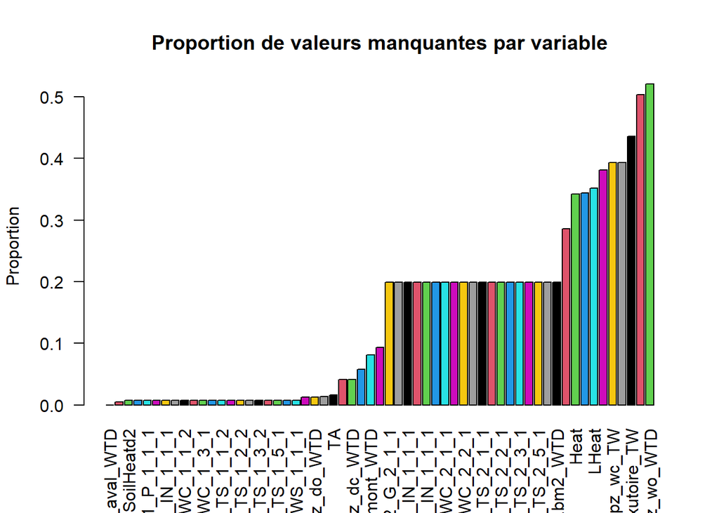

```r
barplot(na_prop, las = 2, col = c(1:60), main = "Proportion de valeurs manquantes par variable",
        ylab = "Proportion")
```

et la variable qui a le plus de manquants est lgt.pz_wo_WTD avec 941 NA.

#### Les variables d’intérêt

Interessons nous à présent aux variables clés qui nous intéressent.

```r
naFCH4<- round((sum(is.na(FCH4)) / nrow(donnees))*100,2) #proportion manquants FCH4
naFCO2<- round((sum(is.na(FCO2)) / nrow(donnees))*100,2) #proportion manquants FCO2

cat("la proportion de FC02 manquant est :",naFCO2, "\n")
```

```
## la proportion de FC02 manquant est : 34.37
```

```r
cat("la proportion de FCH4 manquant est :",naFCH4, "\n")
```

```
## la proportion de FCH4 manquant est : 50.3
```

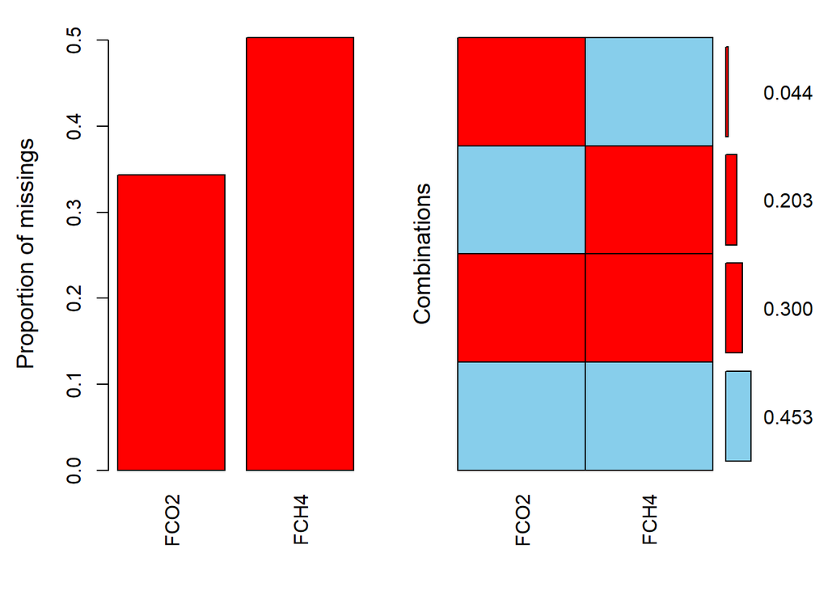

```r
aggr(donnees[, c("FCO2", "FCH4")],numbers=TRUE )
```

Sur ce graphique, chaque barre indique une configuration de présence ou d’absence des deux variables. Voici ce que l’on observe : — 45,3% des observations ont à la fois F CO2 et F CH4 présents. — 30% des observations présentent l’absence simultanée des deux. — 20,3% des cas ont F CH4 manquant alors que F CO2 est présent — 4,4% des cas ont F CO2 manquants et F CH4 présent Ceci renforce la nécessité de choisir une méthode d’imputation adaptée, capable de prendre en compte la structure des données.

### Utilisation de missMDA

plus haut, nous avons vu que notre jeu de données comportent énormément de valeurs manquantes. Ce qui constistue un problème pour la suite de nos analyses (notamment l’acp). Car pour bien faire notre analyse, nous avons besoin de jeux de données complet (sans manquant). C’est pour cela que , nous allons utiliser les outils du package missMDA pour imputer efficacement les valeurs manquantes en s’appuyant sur une approche par ACP.

```r
#estimer le nbre de composante principale à utliser pour imputer efficacement les na

nb1 <- estim_ncpPCA(donnees[,-1], method = "Regularized")$ncp

#on fait l'imputation

dataimp <- imputePCA(donnees[,-1], ncp = nb1, method = "Regularized")$completeObs
```

#### petits réglages

Nous utilisons le format dataframe pour notre jeu de données parce que nous sommes habitués à utiliser ce format.

```r
#detach(donnees)
class(dataimp)
```

```
## [1] "matrix" "array"
```

```r
dataimp = data.frame(date,dataimp)
class(dataimp)
```

```
## [1] "data.frame"
```

```r
#dim(data_impute)
dim(dataimp)
```

```
## [1] 1807   60
```

```r
dim(donnees)
```

```
## [1] 1807   60
```

```r
summary(dataimp)
```

```
##       date                 ETR                 FCO2
##  Min.   :2017-01-19   Min.   :-0.081941   Min.   :-14.6950
##  1st Qu.:2018-04-15   1st Qu.: 0.005029   1st Qu.: -3.4310
##  Median :2019-07-11   Median : 0.035192   Median : -0.1272
##  Mean   :2019-07-10   Mean   : 0.067131   Mean   : -1.2126
##  3rd Qu.:2020-10-04   3rd Qu.: 0.104496   3rd Qu.:  1.0491
##  Max.   :2021-12-30   Max.   : 0.632089   Max.   : 11.3887
##       FCH4                Heat             LHeat           SoilHeatd2
##  Min.   :-0.124422   Min.   :-83.635   Min.   :-61.470   Min.   :-19.250
##  1st Qu.:-0.038638   1st Qu.:  4.638   1st Qu.:  8.058   1st Qu.: -4.430
##  Median :-0.014251   Median : 44.346   Median : 35.248   Median : -1.284
##  Mean   :-0.020132   Mean   : 56.827   Mean   : 55.049   Mean   : -1.369
##  3rd Qu.:-0.002227   3rd Qu.:106.906   3rd Qu.: 90.865   3rd Qu.:  1.717
##  Max.   : 0.056765   Max.   :335.518   Max.   :342.681   Max.   : 14.569
##  lgt.bm1_G_1_1_2   lgt.bm1_P_1_1_1   lgt.bm1_PA_1_1_1 lgt.bm1_PPFD_IN_1_1_1
##  Min.   :-32.452   Min.   :-0.2599   Min.   : 961.5   Min.   :  0.0
##  1st Qu.: -5.069   1st Qu.: 0.0000   1st Qu.: 994.9   1st Qu.:123.5
##  Median : -1.923   Median : 0.2000   Median : 999.6   Median :265.3
##  Mean   : -1.716   Mean   : 1.8520   Mean   : 999.1   Mean   :273.5
##  3rd Qu.:  1.426   3rd Qu.: 1.8000   3rd Qu.:1004.0   3rd Qu.:411.1
##  Max.   : 16.272   Max.   :43.8000   Max.   :1023.2   Max.   :635.5
##  lgt.bm1_RH_1_1_1 lgt.bm1_SWC_1_1_1 lgt.bm1_SWC_1_1_2 lgt.bm1_SWC_1_2_1
##  Min.   :44.12    Min.   : 0.00     Min.   :29.92     Min.   : 0.00
##  1st Qu.:76.26    1st Qu.:34.18     1st Qu.:69.36     1st Qu.:70.04
##  Median :84.26    Median :40.84     Median :72.62     Median :76.53
##  Mean   :82.91    Mean   :37.43     Mean   :70.37     Mean   :69.59
##  3rd Qu.:90.63    3rd Qu.:47.04     3rd Qu.:74.53     3rd Qu.:77.74
##  Max.   :99.98    Max.   :64.09     Max.   :77.05     Max.   :79.43
##  lgt.bm1_SWC_1_3_1       TA         lgt.bm1_TS_1_1_1 lgt.bm1_TS_1_1_2
##  Min.   :64.77     Min.   :-6.430   Min.   :-2.356   Min.   :-1.184
##  1st Qu.:73.57     1st Qu.: 6.443   1st Qu.: 5.949   1st Qu.: 6.370
##  Median :73.87     Median :10.728   Median : 9.867   Median :10.700
##  Mean   :73.63     Mean   :10.744   Mean   :10.128   Mean   :10.917
##  3rd Qu.:74.32     3rd Qu.:15.359   3rd Qu.:14.720   3rd Qu.:15.894
##  Max.   :74.71     Max.   :26.062   Max.   :21.754   Max.   :22.762
##  lgt.bm1_TS_1_2_1  lgt.bm1_TS_1_2_2 lgt.bm1_TS_1_3_1  lgt.bm1_TS_1_3_2
##  Min.   :-0.7548   Min.   :-1.322   Min.   : 0.3654   Min.   :-0.7641
##  1st Qu.: 6.1729   1st Qu.: 6.399   1st Qu.: 6.4224   1st Qu.: 6.3127
##  Median :10.0808   Median :10.705   Median :10.0846   Median :10.3952
##  Mean   :10.3748   Mean   :10.940   Mean   :10.4913   Mean   :10.7463
```

[output cut: 57 more lines]

```
##  Max.   :76.16     Max.   :21.1079   Max.   :20.773   Max.   :22.1505
##  lgt.bm2_TS_2_2_2  lgt.bm2_TS_2_3_1 lgt.bm2_TS_2_4_1 lgt.bm2_TS_2_5_1
##  Min.   :-0.4046   Min.   : 1.250   Min.   : 0.233   Min.   : 2.521
##  1st Qu.: 5.9969   1st Qu.: 7.399   1st Qu.: 6.038   1st Qu.: 7.244
##  Median : 9.7373   Median :11.337   Median : 9.430   Median :10.301
##  Mean   :10.2244   Mean   :11.702   Mean   : 9.995   Mean   :10.751
##  3rd Qu.:14.8532   3rd Qu.:16.297   3rd Qu.:14.426   3rd Qu.:14.646
##  Max.   :20.8620   Max.   :22.662   Max.   :19.339   Max.   :18.658
##  lgt.bm2_TS_2_6_1  lgt.bm2_WTD
##  Min.   : 4.172   Min.   :-0.56381
##  1st Qu.: 7.871   1st Qu.:-0.09428
##  Median :10.394   Median :-0.03965
##  Mean   :10.710   Mean   :-0.07539
##  3rd Qu.:13.917   3rd Qu.:-0.03021
##  Max.   :16.892   Max.   : 0.28558
```

Vérifions qu’il n’y a plus de na

```r
dim(dataimp)
```

```
## [1] 1807   60
```

```r
sum(is.na(dataimp))
```

```
## [1] 0
```

####vérification visuelle de l’imputation

```r
s_FCO2 <- xts(dataimp[, "FCO2"],order.by = date)
s_FCH4 <- xts(dataimp[, "FCH4"],order.by = date)
dygraph(s_FCO2, main = "Imputation PCA - FCO2")
```

[interactive chart not shown]

```r
dygraph(s_FCH4, main = "Imputation PCA - FCH4")
```

[interactive chart not shown]

Les gros vides représentant les NA ne sont plus présents sur les graphiques;ils ont l’air harmonieux.Pour aller plus loin, regardons le ggplot.

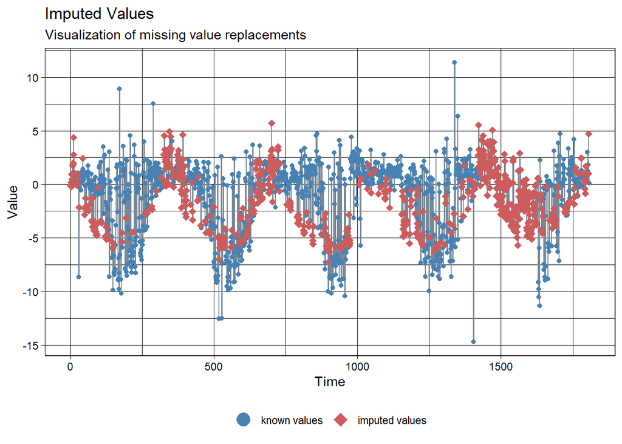

```r
ggplot_na_imputations(donnees[,-1]$FCO2, s_FCO2)
```

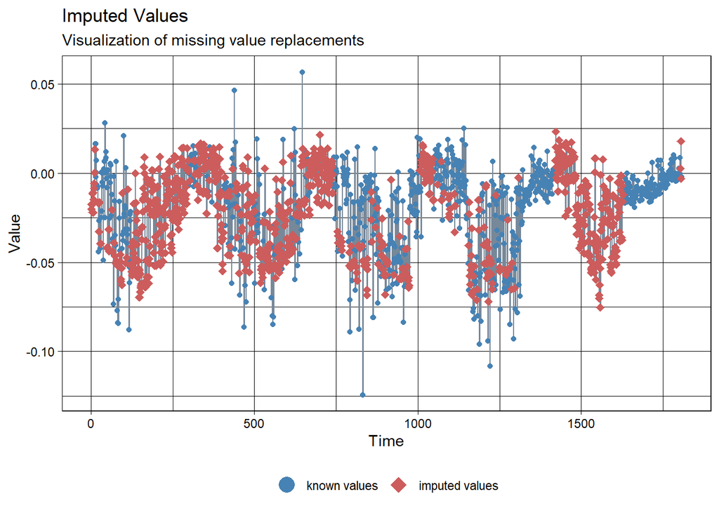

```r
ggplot_na_imputations(donnees[,-1]$FCH4, s_FCH4)
```

Les points rouges semblent s’intégrés aux différents graphique de manière harmonieuse. Ce qui peut être un bon signe.

#### vérifions avec des outils plus sophistiqués

```r
library(missForest)  # pour prodNA()
set.seed(123)

# 10% de données manquantes artificielles
dondate = dataimp[,-1]
data_na <- prodNA(dondate, noNA = 0.1)

# Imputation
res <- imputePCA(data_na, ncp = 3, method = "Regularized")

# Comparaison
true_values <- dondate[is.na(data_na)]
imputed_values <- res$completeObs[is.na(data_na)]

# Erreur quadratique moyenne
rmse <- sqrt(mean((true_values - imputed_values)^2))
print(rmse)
```

```
## [1] 13.6516
```

```r
summary(dataimp$FCO2)
```

```
##     Min.  1st Qu.   Median     Mean  3rd Qu.     Max.
## -14.6950  -3.4310  -0.1272  -1.2126   1.0491  11.3887
```

```r
summary(donnees$FCO2)
```

```
##     Min.  1st Qu.   Median     Mean  3rd Qu.     Max.     NA's
## -14.6950  -3.1503   0.2196  -1.1414   1.0914  11.3887      621
```

```r
sd(dataimp$FCO2, na.rm = TRUE)
```

```
## [1] 3.239895
```

```r
sd(donnees$FCO2, na.rm = TRUE)
```

```
## [1] 3.483126
```

```r
summary(dataimp$FCH4)
```

```
##      Min.   1st Qu.    Median      Mean   3rd Qu.      Max.
## -0.124422 -0.038638 -0.014251 -0.020132 -0.002227  0.056765
```

```r
summary(donnees$FCH4)
```

```
##    Min. 1st Qu.  Median    Mean 3rd Qu.    Max.    NA's
## -0.1244 -0.0296 -0.0107 -0.0180 -0.0025  0.0568     909
```

```r
sd(dataimp$FCH4, na.rm = TRUE)
```

```
## [1] 0.02354836
```

```r
sd(donnees$FCH4, na.rm = TRUE)
```

```
## [1] 0.02377391
```

Les variables gardant globalement les mêmes valeurs extrêmes et comme on a un rmse relativement bas, on peut dire que l’imputation a été réussi.

```r
donnees_st <- xts(dataimp, order.by = date) # Version time serie
```

```r
attach(dataimp)
```

```
## L'objet suivant est masqué _par_ .GlobalEnv:
##
##     date
```

[output not shown]

#### enregistrement des données completées

```r
save(dataimp, file = "mes_donnees1.RData")
```

### Partie ACP

Nous voulons faire une ACP pour mieux comprendre les dynamiques dans notre jeu de données. Sachant que les variables n’ont pas toutes les mêmes unités et aussi sachant qu’il y a quelques valeurs abérrantes, nous avons pensés à faire une acp normée mais, regardons les variances et les écarts type pour confirmer.

```r
print(apply(dataimp[,-1],2,sd),3)
```

```
##                   ETR                  FCO2                  FCH4
##                0.0905                3.2399                0.0235
##                  Heat                 LHeat            SoilHeatd2
##               63.5869               63.0852                4.4910
##       lgt.bm1_G_1_1_2       lgt.bm1_P_1_1_1      lgt.bm1_PA_1_1_1
##                5.0502                3.7938                8.1587
## lgt.bm1_PPFD_IN_1_1_1      lgt.bm1_RH_1_1_1     lgt.bm1_SWC_1_1_1
##              163.3084               10.4681               12.7391
##     lgt.bm1_SWC_1_1_2     lgt.bm1_SWC_1_2_1     lgt.bm1_SWC_1_3_1
##                7.5184               17.1617                1.4127
##                    TA      lgt.bm1_TS_1_1_1      lgt.bm1_TS_1_1_2
##                5.9396                5.4224                5.6102
##      lgt.bm1_TS_1_2_1      lgt.bm1_TS_1_2_2      lgt.bm1_TS_1_3_1
##                5.2569                5.6487                4.8218
##      lgt.bm1_TS_1_3_2      lgt.bm1_TS_1_4_1      lgt.bm1_TS_1_5_1
##                5.2771                4.3949                3.0928
##      lgt.bm1_WD_1_1_1      lgt.bm1_WS_1_1_1           lgt.bm1_WTD
##               46.9282                0.4709                0.0907
##     lgt.sm_exutoire_Q    lgt.sm_exutoire_TW  lgt.pz_cbdv_amont_TW
##               11.3094                2.4639                3.0888
## lgt.pz_cbdv_amont_WTD   lgt.pz_cbdv_aval_TW  lgt.pz_cbdv_aval_WTD
##                0.1210                3.3199                0.0965
##          lgt.pz_dc_TW         lgt.pz_dc_WTD          lgt.pz_do_TW
##                2.4709                0.1573                4.3898
##         lgt.pz_do_WTD          lgt.pz_wc_TW         lgt.pz_wc_WTD
##                0.0763                2.6160                0.0880
##         lgt.pz_wo_WTD       lgt.bm2_G_2_1_1       lgt.bm2_G_2_1_2
##                0.0781                4.6349                4.1569
##   lgt.bm2_LW_IN_1_1_1  lgt.bm2_LW_OUT_1_1_1   lgt.bm2_SW_IN_1_1_1
##               32.3417               31.2022               73.6420
##  lgt.bm2_SW_OUT_1_1_1     lgt.bm2_SWC_2_1_1     lgt.bm2_SWC_2_1_2
##               13.3691                9.5541               11.8523
##     lgt.bm2_SWC_2_2_1     lgt.bm2_SWC_2_3_1      lgt.bm2_TS_2_1_1
##                5.3816                1.2288                5.1485
##      lgt.bm2_TS_2_1_2      lgt.bm2_TS_2_2_1      lgt.bm2_TS_2_2_2
##                5.2794                5.1189                5.0933
##      lgt.bm2_TS_2_3_1      lgt.bm2_TS_2_4_1      lgt.bm2_TS_2_5_1
##                5.0455                4.7017                4.0461
##      lgt.bm2_TS_2_6_1           lgt.bm2_WTD
##                3.2364                0.1188
```

```r
sdmen <- apply(dataimp[,-1],2,sd)
max(sdmen)/min(sdmen)
```

```
## [1] 6935.022
```

# Acp normé

```r
acpj <- dudi.pca(dataimp[,-c(1,3,4)], scale = TRUE, scannf = F, nf =7) #ACP normée sans date, FCO2 et FCH4
class(acpj)
```

```
## [1] "pca"  "dudi"
```

```r
names(acpj)
```

```
##  [1] "tab"  "cw"   "lw"   "eig"  "rank" "nf"   "c1"   "li"   "co"   "l1"
## [11] "call" "cent" "norm"
```

```r
head(acpj$li)  ## Coordonnees des individus suivant les axes factoriels
```

```
##      Axis1    Axis2     Axis3      Axis4      Axis5       Axis6        Axis7
## 1 9.783221 1.705149 -3.625396 -0.5150380 -0.4523877 -0.07840391  0.030758432
## 2 9.580653 1.825549 -3.178512  0.4500937 -0.4065486 -0.30173915  0.002255908
## 3 9.552377 2.507779 -2.908018  0.4809695 -0.4543654 -0.34819163 -0.254157288
## 4 9.468112 2.755260 -3.466829  0.5250097 -0.1306031 -0.46402974 -0.208497367
## 5 9.653005 2.936922 -1.911964  0.9350593 -1.0341262 -0.32221586 -0.523903505
## 6 9.779735 2.953519 -1.992313  0.4909171 -0.5795725 -0.43610604 -0.332410404
```

#### inertie

```r
inertie <- inertia.dudi(acpj, col.inertia = F, row.inertia = T) ## ici on fait acp des lignes
names (inertie)
```

```
## [1] "tot.inertia" "row.contrib" "row.abs"     "row.rel"     "row.cum"
## [6] "nf"          "call"
```

```r
inertie$tot.inertia
```

```
##           inertia      cum    cum(%)
## Ax1  2.946403e+01 29.46403  51.69128
## Ax2  9.278844e+00 38.74287  67.96996
## Ax3  5.877332e+00 44.62021  78.28106
## Ax4  3.773572e+00 48.39378  84.90137
## Ax5  1.574224e+00 49.96800  87.66316
## Ax6  8.908973e-01 50.85890  89.22614
## Ax7  8.721185e-01 51.73102  90.75617
## Ax8  7.732400e-01 52.50426  92.11273
## Ax9  6.851419e-01 53.18940  93.31474
## Ax10 5.624855e-01 53.75189  94.30155
## Ax11 4.452057e-01 54.19709  95.08262
## Ax12 3.733960e-01 54.57049  95.73770
## Ax13 3.181890e-01 54.88868  96.29592
## Ax14 2.413269e-01 55.13000  96.71930
## Ax15 2.393172e-01 55.36932  97.13916
## Ax16 1.932826e-01 55.56260  97.47825
## Ax17 1.852712e-01 55.74787  97.80329
## Ax18 1.549263e-01 55.90280  98.07509
## Ax19 1.257045e-01 56.02850  98.29562
## Ax20 1.093928e-01 56.13790  98.48754
## Ax21 9.766335e-02 56.23556  98.65888
## Ax22 8.506627e-02 56.32063  98.80812
## Ax23 7.731220e-02 56.39794  98.94375
## Ax24 7.372785e-02 56.47167  99.07310
## Ax25 6.642920e-02 56.53810  99.18964
## Ax26 5.754273e-02 56.59564  99.29059
## Ax27 5.007093e-02 56.64571  99.37844
## Ax28 4.240595e-02 56.68812  99.45283
## Ax29 3.688392e-02 56.72500  99.51754
## Ax30 3.415604e-02 56.75916  99.57747
## Ax31 3.197138e-02 56.79113  99.63356
## Ax32 2.913933e-02 56.82027  99.68468
## Ax33 2.580955e-02 56.84608  99.72996
## Ax34 1.999215e-02 56.86607  99.76503
## Ax35 1.793003e-02 56.88400  99.79649
## Ax36 1.723882e-02 56.90124  99.82673
## Ax37 1.602161e-02 56.91726  99.85484
## Ax38 1.278938e-02 56.93005  99.87728
## Ax39 1.233127e-02 56.94238  99.89891
## Ax40 1.011313e-02 56.95249  99.91665
## Ax41 9.831155e-03 56.96232  99.93390
## Ax42 8.463571e-03 56.97079  99.94875
## Ax43 6.664140e-03 56.97745  99.96044
## Ax44 5.436750e-03 56.98289  99.96998
## Ax45 4.284811e-03 56.98717  99.97750
## Ax46 3.965969e-03 56.99114  99.98445
## Ax47 2.828395e-03 56.99397  99.98942
## Ax48 2.184523e-03 56.99615  99.99325
## Ax49 1.243360e-03 56.99740  99.99543
## Ax50 7.691482e-04 56.99816  99.99678
## Ax51 6.688700e-04 56.99883  99.99795
## Ax52 4.377242e-04 56.99927  99.99872
## Ax53 2.672366e-04 56.99954  99.99919
## Ax54 2.004769e-04 56.99974  99.99954
## Ax55 1.748418e-04 56.99991  99.99985
## Ax56 6.612510e-05 56.99998  99.99996
## Ax57 2.046092e-05 57.00000 100.00000
```

#### tracons l’ébouli des valeurs propres

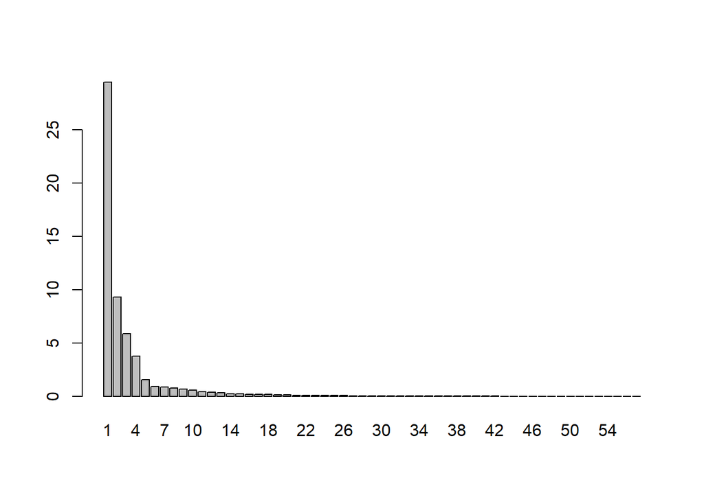

```r
barplot(acpj$eig,names.arg=1:length(dataimp[,-c(1,3,4)])) #tracé de l'éboulis des valeurs propres
```

#### la corrélation entre les variables

Nous voulons voir s’il y a une dynamique dans les données.

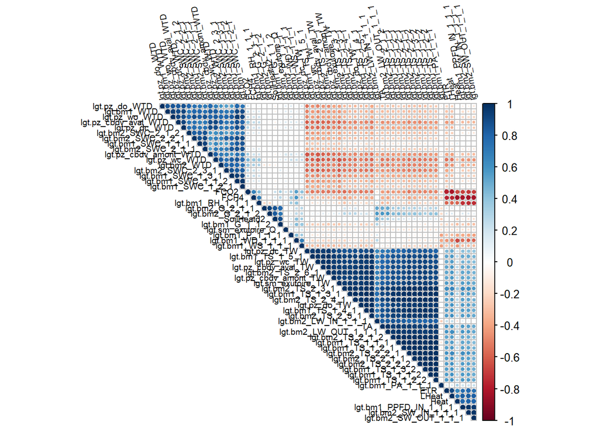

```r
# la correlation entre les variables

mcorr<-as.matrix(cor(dataimp[,-1], use = "complete.obs"))  ## Matrice de correlation en ignorant les valeurs manquantes
corrplot(mcorr,type="upper",tl.cex=0.6, order="hclust",tl.col="black",tl.srt=100 )
```

## Les cercles de corrélation

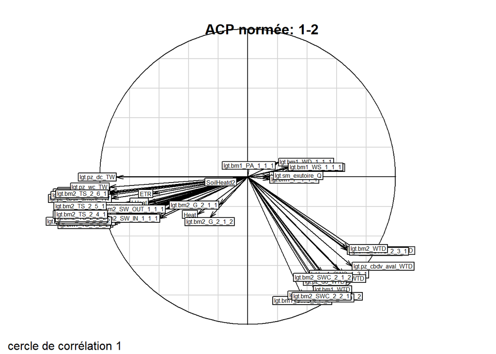

```r
s.corcircle(acpj$co,clabel = 0.5 ,sub = " cercle de corrélation 1") # plan principal
title ( "ACP normée: 1-2")
```

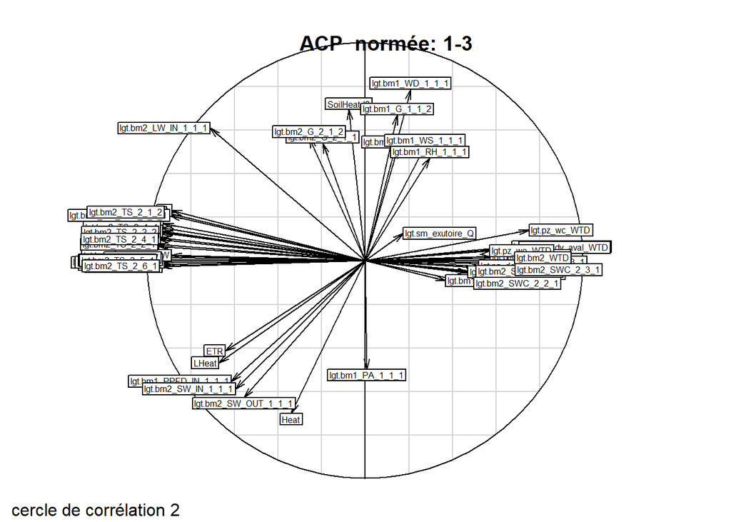

```r
s.corcircle(acpj$co,yax=3,clabel = 0.5,sub = " cercle de corrélation 2")
title ( "ACP  normée: 1-3")
```

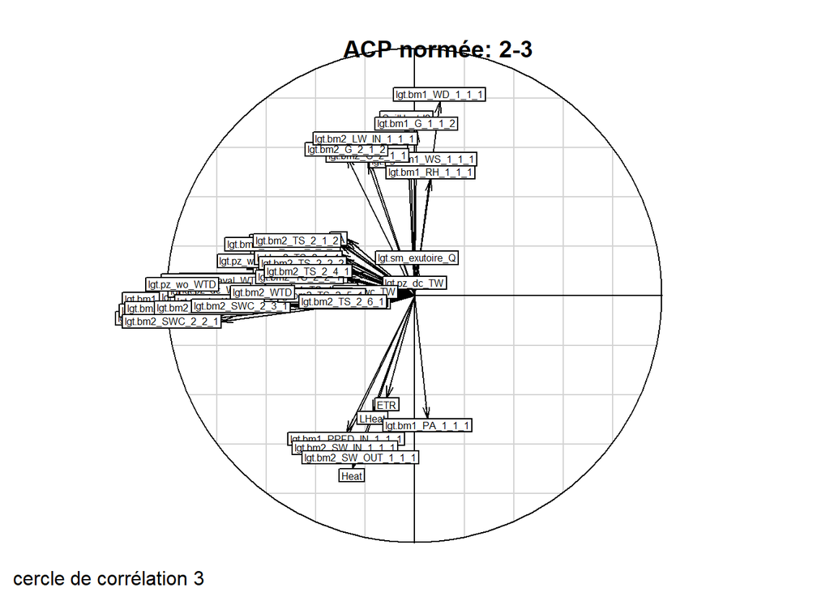

```r
s.corcircle(acpj$co,xax=2,yax=3,clabel = 0.5,sub = " cercle de corrélation 3")
title ( "ACP normée: 2-3")
```

En somme, l’axe 1 nous pouvons dire que d’un coté l’axe 1 capte les phénomènes liés à la dynamique de l’eau (hydrologique) et de l’autre, il capte les phénomènes thermiques. L’axe 2 quant à lui est lié aux dynamisme hydrique dans la tourbière. Et pour finir, L’axe 3 oppose les phénomènes atmosphériques (vent et humidité) aux phénomènes thermo-biologiques(activité des plantes, evapotranspiration).

### La projection des variables supplementaire (FCO2 et FCH4) sur les axes

Nous cherchons à voir comment les GES se comportent dans la tourbière. A quelles variables sont t ils liés? a quelles variables sont t il opposés?

```r
var_sup <- scale(dataimp[,c(3,4)]) #centre et réduit
cor_sup <- cor(var_sup,acpj$li )  # corrélation avec les axes
head(cor_sup)
```

```
##          Axis1     Axis2     Axis3      Axis4      Axis5        Axis6
## FCO2 0.5620687 0.1400541 0.5213142 -0.1362507 -0.0122597 -0.009794688
## FCH4 0.4325035 0.1676419 0.6179814 -0.4155702 -0.1580959  0.017488381
##             Axis7
## FCO2 0.0005845248
## FCH4 0.0779920009
```

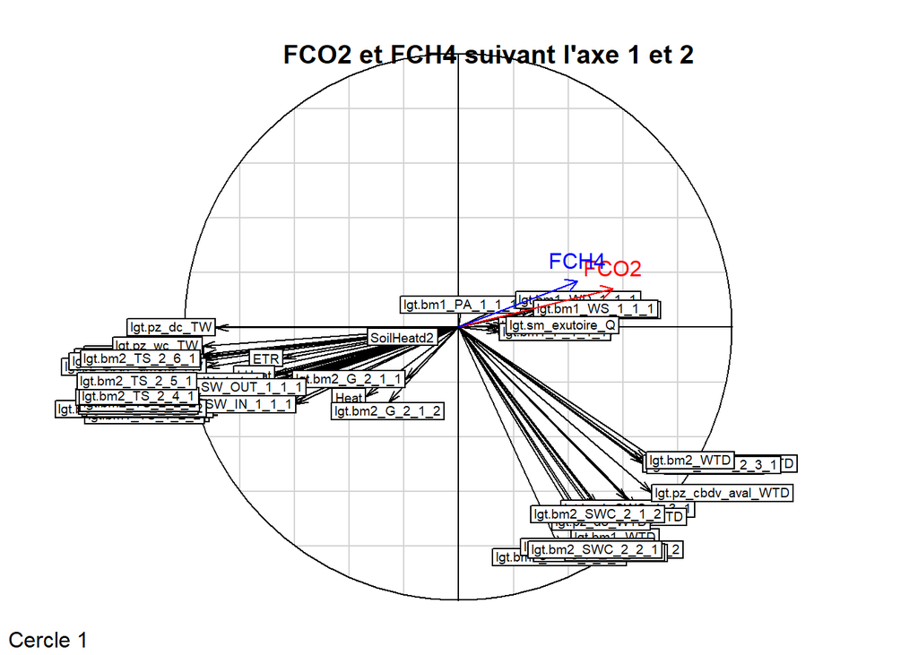

```r
# Ajout de FCO2 et FCH4 au cercle de correlation suivant l'axe 1 et 2

s.corcircle(acpj$co,xax=1,yax=2,clabel=0.6 , sub ="Cercle 1" )  # Cercle des corrélations

arrows(0, 0, cor_sup[1,1], cor_sup[1,2], col = "red", length = 0.1)   #pour faire la flèche
text(cor_sup[1,1], cor_sup[1,2], labels = "FCO2", pos = 3, col = "red") #mettre le texte

arrows(0, 0, cor_sup[2,1], cor_sup[2,2], col = "blue", length = 0.1)
text(cor_sup[2,1], cor_sup[2,2], labels = "FCH4", pos = 3, col = "blue")
title(" FCO2 et FCH4 suivant l'axe 1 et 2")
```

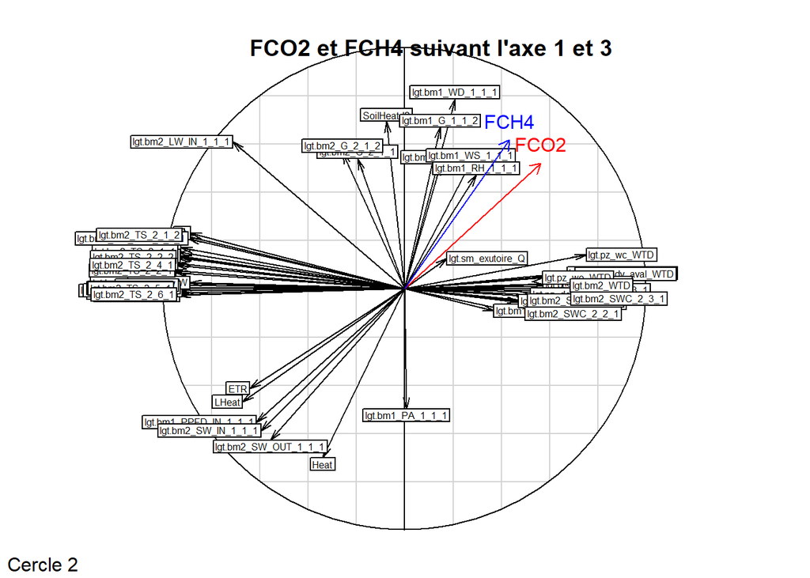

```r
# Ajouter les flèches des variables supplémentaires sur axes 1 et 3

s.corcircle(acpj$co,xax=1,yax=3,clabel=0.5, sub ="Cercle 2")

arrows(0, 0, cor_sup[1,1], cor_sup[1,3], col = "red", length = 0.1)
text(cor_sup[1,1], cor_sup[1,3], labels = "FCO2", pos = 3, col = "red")

arrows(0, 0, cor_sup[2,1], cor_sup[2,3], col = "blue", length = 0.1)
text(cor_sup[2,1], cor_sup[2,3], labels = "FCH4", pos = 3, col = "blue")
title(" FCO2 et FCH4 suivant l'axe 1 et 3")
```

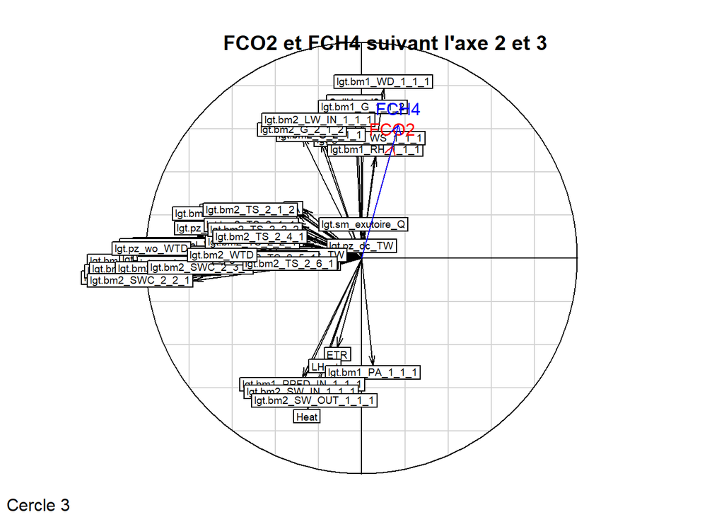

```r
# Ajouter les flèches des variables supplémentaires sur axes 2 et 3

s.corcircle(acpj$co,xax=2,yax=3,clabel=0.6, sub ="Cercle 3")

arrows(0, 0, cor_sup[1,2], cor_sup[1,3], col = "red", length = 0.1)
text(cor_sup[1,2], cor_sup[1,3], labels = "FCO2", pos = 3, col = "red")

arrows(0, 0, cor_sup[2,2], cor_sup[2,3], col = "blue", length = 0.1)
text(cor_sup[2,2], cor_sup[2,3], labels = "FCH4", pos = 3, col = "blue")
title(" FCO2 et FCH4 suivant l'axe 2 et 3")
```

#### Corrélation entr axes et variables

Pour mieux interpréter, regardons la corrélation entre les axes et les variables.

```r
cc<-cor(dataimp[,-c(1,3,4)],acpj$li) # Correlation entre les axes factoriels et les variables
head(cc)
```

```
##                       Axis1        Axis2      Axis3      Axis4       Axis5
## ETR             -0.64236266 -0.112912081 -0.4117836  0.3614661  0.15077137
## Heat            -0.34037014 -0.253990282 -0.6988408  0.3413432  0.02474296
## LHeat           -0.67270809 -0.171605825 -0.4670978  0.3218326  0.07257006
## SoilHeatd2      -0.07630174 -0.034566924  0.6938487  0.6067321 -0.22819176
## lgt.bm1_G_1_1_2  0.14521651  0.006170156  0.6694720  0.5841370 -0.25600572
## lgt.bm1_P_1_1_1  0.14871528 -0.016363875  0.5173986 -0.1858478  0.36479587
##                       Axis6        Axis7
## ETR              0.01444412  0.006339114
## Heat            -0.02415850 -0.101113178
## LHeat            0.02320691  0.053326317
## SoilHeatd2       0.07059406 -0.007600430
## lgt.bm1_G_1_1_2  0.06995551 -0.005794524
## lgt.bm1_P_1_1_1 -0.11438338  0.003105254
```

- A l’axe 1

```r
seuil=0.5
cor1<-cc[abs(cc[,1])>=seuil,,drop=F]
nrow(cor1)
```

```
## [1] 43
```

```r
rownames(cor1)
```

```
##  [1] "ETR"                   "LHeat"                 "lgt.bm1_PPFD_IN_1_1_1"
##  [4] "lgt.bm1_SWC_1_1_2"     "lgt.bm1_SWC_1_2_1"     "lgt.bm1_SWC_1_3_1"
##  [7] "TA"                    "lgt.bm1_TS_1_1_1"      "lgt.bm1_TS_1_1_2"
## [10] "lgt.bm1_TS_1_2_1"      "lgt.bm1_TS_1_2_2"      "lgt.bm1_TS_1_3_1"
## [13] "lgt.bm1_TS_1_3_2"      "lgt.bm1_TS_1_4_1"      "lgt.bm1_TS_1_5_1"
## [16] "lgt.bm1_WTD"           "lgt.sm_exutoire_TW"    "lgt.pz_cbdv_amont_TW"
## [19] "lgt.pz_cbdv_amont_WTD" "lgt.pz_cbdv_aval_TW"   "lgt.pz_cbdv_aval_WTD"
## [22] "lgt.pz_dc_TW"          "lgt.pz_dc_WTD"         "lgt.pz_do_TW"
## [25] "lgt.pz_do_WTD"         "lgt.pz_wc_TW"          "lgt.pz_wc_WTD"
## [28] "lgt.pz_wo_WTD"         "lgt.bm2_LW_IN_1_1_1"   "lgt.bm2_LW_OUT_1_1_1"
## [31] "lgt.bm2_SW_IN_1_1_1"   "lgt.bm2_SW_OUT_1_1_1"  "lgt.bm2_SWC_2_1_2"
## [34] "lgt.bm2_SWC_2_3_1"     "lgt.bm2_TS_2_1_1"      "lgt.bm2_TS_2_1_2"
## [37] "lgt.bm2_TS_2_2_1"      "lgt.bm2_TS_2_2_2"      "lgt.bm2_TS_2_3_1"
## [40] "lgt.bm2_TS_2_4_1"      "lgt.bm2_TS_2_5_1"      "lgt.bm2_TS_2_6_1"
## [43] "lgt.bm2_WTD"
```

- A l’axe 1 négativement

```r
cor1N<-cc[cc[,1]<=(-seuil),,drop=F]
nrow(cor1N)
```

```
## [1] 30
```

```r
rownames(cor1N)
```

```
##  [1] "ETR"                   "LHeat"                 "lgt.bm1_PPFD_IN_1_1_1"
##  [4] "TA"                    "lgt.bm1_TS_1_1_1"      "lgt.bm1_TS_1_1_2"
##  [7] "lgt.bm1_TS_1_2_1"      "lgt.bm1_TS_1_2_2"      "lgt.bm1_TS_1_3_1"
## [10] "lgt.bm1_TS_1_3_2"      "lgt.bm1_TS_1_4_1"      "lgt.bm1_TS_1_5_1"
## [13] "lgt.sm_exutoire_TW"    "lgt.pz_cbdv_amont_TW"  "lgt.pz_cbdv_aval_TW"
## [16] "lgt.pz_dc_TW"          "lgt.pz_do_TW"          "lgt.pz_wc_TW"
## [19] "lgt.bm2_LW_IN_1_1_1"   "lgt.bm2_LW_OUT_1_1_1"  "lgt.bm2_SW_IN_1_1_1"
## [22] "lgt.bm2_SW_OUT_1_1_1"  "lgt.bm2_TS_2_1_1"      "lgt.bm2_TS_2_1_2"
## [25] "lgt.bm2_TS_2_2_1"      "lgt.bm2_TS_2_2_2"      "lgt.bm2_TS_2_3_1"
## [28] "lgt.bm2_TS_2_4_1"      "lgt.bm2_TS_2_5_1"      "lgt.bm2_TS_2_6_1"
```

- A l’axe 1 positivement

```r
cor1p<-cc[cc[,1]>=(seuil),,drop=F]
nrow(cor1p)
```

```
## [1] 13
```

```r
rownames(cor1p)
```

```
##  [1] "lgt.bm1_SWC_1_1_2"     "lgt.bm1_SWC_1_2_1"     "lgt.bm1_SWC_1_3_1"
##  [4] "lgt.bm1_WTD"           "lgt.pz_cbdv_amont_WTD" "lgt.pz_cbdv_aval_WTD"
##  [7] "lgt.pz_dc_WTD"         "lgt.pz_do_WTD"         "lgt.pz_wc_WTD"
## [10] "lgt.pz_wo_WTD"         "lgt.bm2_SWC_2_1_2"     "lgt.bm2_SWC_2_3_1"
## [13] "lgt.bm2_WTD"
```

- A l’axe 2

```r
cor2<-cc[abs(cc[,2])>=seuil,,drop=F]
nrow(cor2)
```

```
## [1] 14
```

```r
rownames(cor2)
```

```
##  [1] "lgt.bm1_SWC_1_1_1"    "lgt.bm1_SWC_1_1_2"    "lgt.bm1_SWC_1_2_1"
##  [4] "lgt.bm1_SWC_1_3_1"    "lgt.bm1_WTD"          "lgt.pz_cbdv_aval_WTD"
##  [7] "lgt.pz_dc_WTD"        "lgt.pz_do_WTD"        "lgt.pz_wc_WTD"
## [10] "lgt.pz_wo_WTD"        "lgt.bm2_SWC_2_1_1"    "lgt.bm2_SWC_2_1_2"
## [13] "lgt.bm2_SWC_2_2_1"    "lgt.bm2_SWC_2_3_1"
```

- A l’axe 2 négativement

```r
cor2N<-cc[cc[,2]<=(-seuil),,drop=F]
nrow(cor2N)
```

```
## [1] 14
```

```r
rownames(cor2N)
```

```
##  [1] "lgt.bm1_SWC_1_1_1"    "lgt.bm1_SWC_1_1_2"    "lgt.bm1_SWC_1_2_1"
##  [4] "lgt.bm1_SWC_1_3_1"    "lgt.bm1_WTD"          "lgt.pz_cbdv_aval_WTD"
##  [7] "lgt.pz_dc_WTD"        "lgt.pz_do_WTD"        "lgt.pz_wc_WTD"
## [10] "lgt.pz_wo_WTD"        "lgt.bm2_SWC_2_1_1"    "lgt.bm2_SWC_2_1_2"
## [13] "lgt.bm2_SWC_2_2_1"    "lgt.bm2_SWC_2_3_1"
```

- A l’axe 2 positivement

```r
cor2p<-cc[cc[,2]>=(seuil),,drop=F]
nrow(cor2p)
```

```
## [1] 0
```

```r
rownames(cor2p)
```

A l’axe 3

```r
cor3<-cc[abs(cc[,3])>=seuil,,drop=F]
nrow(cor3)
```

```
## [1] 12
```

```r
rownames(cor3)
```

```
##  [1] "Heat"                  "SoilHeatd2"            "lgt.bm1_G_1_1_2"
##  [4] "lgt.bm1_P_1_1_1"       "lgt.bm1_PPFD_IN_1_1_1" "lgt.bm1_WD_1_1_1"
##  [7] "lgt.bm1_WS_1_1_1"      "lgt.bm2_G_2_1_1"       "lgt.bm2_G_2_1_2"
## [10] "lgt.bm2_LW_IN_1_1_1"   "lgt.bm2_SW_IN_1_1_1"   "lgt.bm2_SW_OUT_1_1_1"
```

- A l’axe 3 négativement

```r
cor3N<-cc[cc[,3]<=(-seuil),,drop=F]
nrow(cor3N)
```

```
## [1] 4
```

```r
rownames(cor3N)
```

```
## [1] "Heat"                  "lgt.bm1_PPFD_IN_1_1_1" "lgt.bm2_SW_IN_1_1_1"
## [4] "lgt.bm2_SW_OUT_1_1_1"
```

- A l’axe 3 positivement

```r
cor3p<-cc[cc[,3]>=(seuil),,drop=F]
nrow(cor3p)
```

```
## [1] 8
```

```r
rownames(cor3p)
```

```
## [1] "SoilHeatd2"          "lgt.bm1_G_1_1_2"     "lgt.bm1_P_1_1_1"
## [4] "lgt.bm1_WD_1_1_1"    "lgt.bm1_WS_1_1_1"    "lgt.bm2_G_2_1_1"
## [7] "lgt.bm2_G_2_1_2"     "lgt.bm2_LW_IN_1_1_1"
```

#### Correlations des FCO2 et CH4 axes suivant les 3 axes

```r
cor_sup[,1:4]
```

```
##          Axis1     Axis2     Axis3      Axis4
## FCO2 0.5620687 0.1400541 0.5213142 -0.1362507
## FCH4 0.4325035 0.1676419 0.6179814 -0.4155702
```

#### Commentaire

En résumé, nous observons que FCO2 présente une corrélation de 0.56 avec l’axe 1 et de 0.52 avec l’axe 3. Pour FCH4, la corrélation est plus marquée avec l’axe 3 (0.62) qu’avec l’axe 1 (0.43). Les deux variables sont très peu présent en ce qui concerne l’axe 2.L’axe 1, que nous avons interprété comme opposant les variables thermiques (température du sol, évapotranspiration) aux variables hydriques (teneur en eau du sol, profondeur de la nappe), semble fortement associé au flux de CO2. Cette corrélation positive suggère que les variations thermiques de la tourbière ont un impact sur le flux de CO2. Le flux est surement réduit lorsque la température augmente. L’axe 3, représentant l’opposition entre phénomènes atmosphériques (vent, rayonnement à ondes longues) et chaleur sensible ou rayonnement solaire, est corrélé à la fois à FCO2 et FCH4. Cette association, plus marquée pour FCH4, indique que les conditions atmosphériques, telles que la circulation du vent et l’humidité de l’air, pourraient influencer la dynamique d’émission de ces gaz à effet de serre. Ces résultats confirment l’importance de considérer à la fois les phénomènes thermiques et les conditions atmosphériques pour expliquer les variations des flux de CO2 et CH4 dans la tourbière.

#### Représentons le plan factoriel, barycentré sur les mois

```r
mois <-format(date, format = "%m")
mois1 <- factor(mois,
               levels = sprintf("%02d", 1:12),
               labels = c("Janvier", "Février", "Mars", "Avril", "Mai", "Juin",
                          "Juillet", "Août", "Septembre", "Octobre", "Novembre", "Décembre"),
               ordered = TRUE)
```

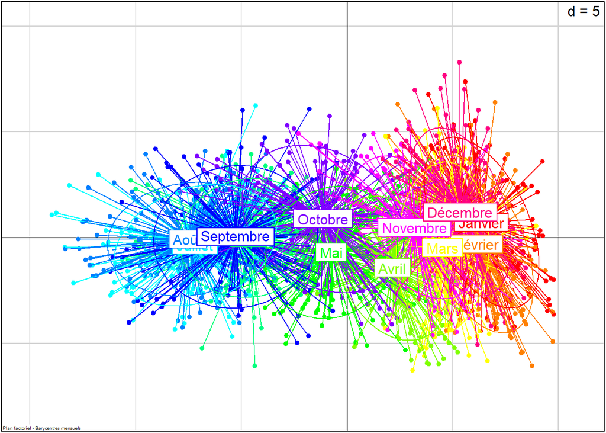

```r
 #  Représentation graphique axe 1-3 : groupé par mois
s.class(acpj$li[,c(1,3)], fac = mois1, col = rainbow(length(unique(mois))),
        sub = "Plan factoriel - Barycentres mensuels",
        csub = 0.3)
```

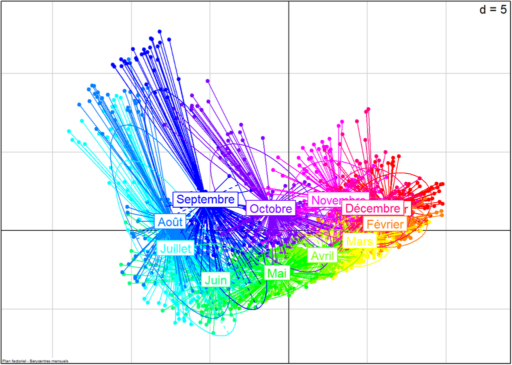

```r
 #  Représentation graphique axe 1-2 : groupé par mois
s.class(acpj$li[,c(1,2)], fac = mois1, col = rainbow(length(unique(mois))),
        sub = "Plan factoriel - Barycentres mensuels",
        csub = 0.3)
```

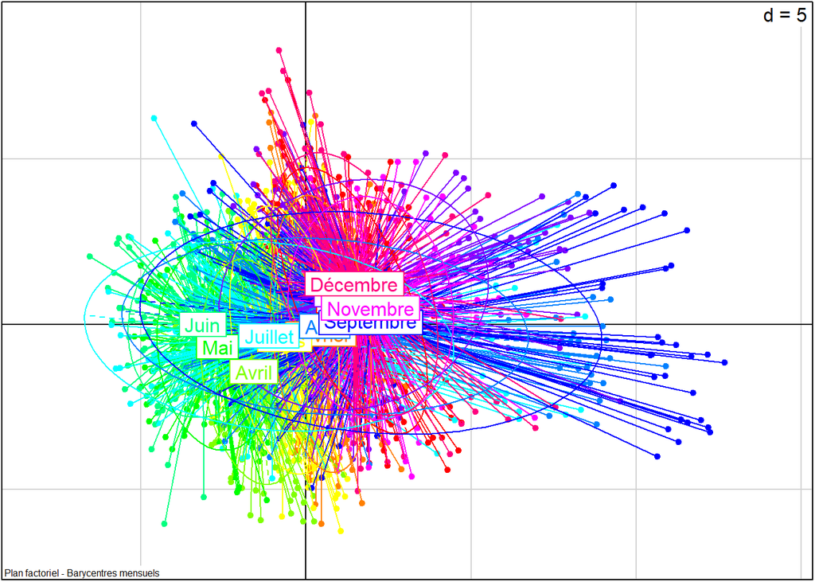

```r
 #  Représentation graphique axe 2-3 : groupé par mois
s.class(acpj$li[,c(2,3)], fac = mois1, col = rainbow(length(unique(mois))),
        sub = "Plan factoriel - Barycentres mensuels",
        csub = 0.5)
```

#### Représentons le plan factoriel, barycentré sur les années

```r
annee <-format(date, format = "%Y")
annee1 <- factor(annee,
               levels = c("2017", "2018", "2019", "2020", "2021"),
               ordered = TRUE)
```

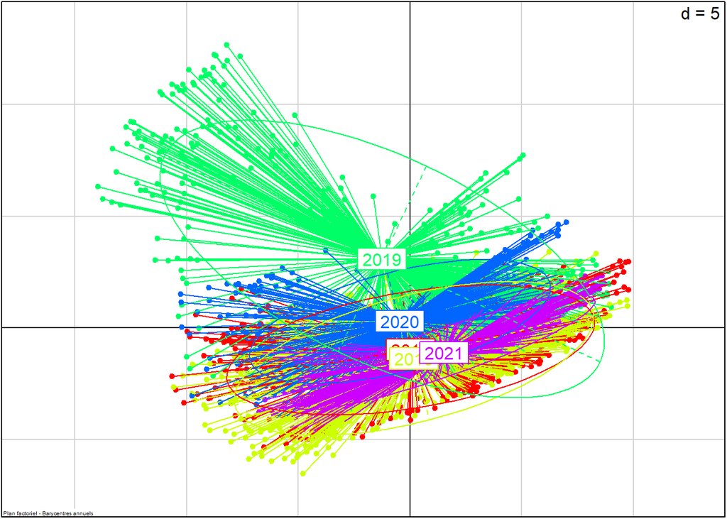

```r
 #  Représentation graphique axe 1-2 : groupé par année
s.class(acpj$li[,c(1,2)], fac = annee1, col = rainbow(length(unique(annee1))),
        sub = "Plan factoriel - Barycentres annuels",
        csub = 0.3)
```

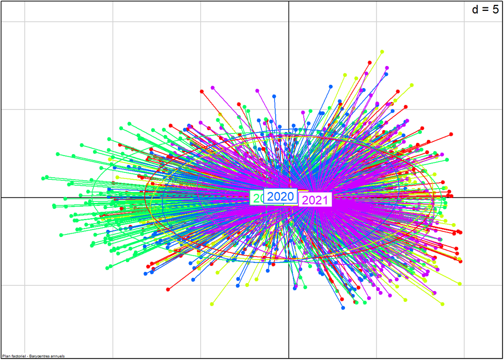

```r
 #  Représentation graphique axe 1-3 : groupé par année
s.class(acpj$li[,c(1,3)], fac = annee1, col = rainbow(length(unique(annee1))),
        sub = "Plan factoriel - Barycentres annuels",
        csub = 0.3)
```

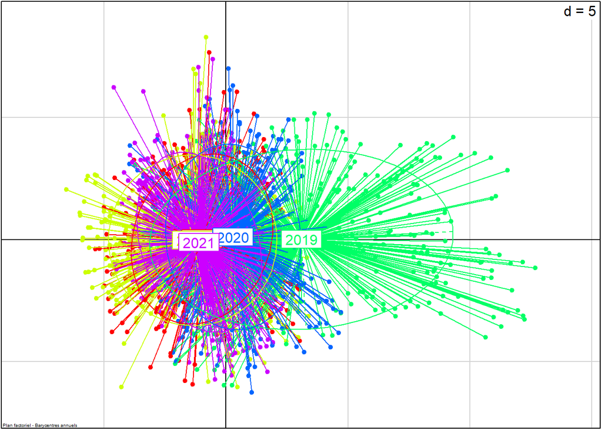

```r
 #  Représentation graphique axe 2-3 : groupé par année
s.class(acpj$li[,c(2,3)], fac = annee1, col = rainbow(length(unique(annee1))),
        sub = "Plan factoriel - Barycentres annuels",
        csub = 0.3)
```

### Pour aller plus loin

Nous avons inclus la composante 4 dans nos analyse pour voir si elle nous apporte plus d’information. Cet ajout n’est pas démésurée car avec les 4 axes, nous arrivons à capter plus de 80% de l’information disponible ce qui est énorme.

- A l’axe 4

```r
cor4<-cc[abs(cc[,4])>=seuil,,drop=F]
nrow(cor4)
```

```
## [1] 5
```

```r
rownames(cor4)
```

```
## [1] "SoilHeatd2"       "lgt.bm1_G_1_1_2"  "lgt.bm1_RH_1_1_1" "lgt.bm2_G_2_1_1"
## [5] "lgt.bm2_G_2_1_2"
```

- A l’axe 4 négativement

```r
cor4N<-cc[cc[,4]<=(-seuil),,drop=F]
nrow(cor4N)
```

```
## [1] 1
```

```r
rownames(cor4N)
```

```
## [1] "lgt.bm1_RH_1_1_1"
```

- A l’axe 4 positivement

```r
cor4p<-cc[cc[,4]>=(seuil),,drop=F]
nrow(cor4p)
```

```
## [1] 4
```

```r
rownames(cor4p)
```

```
## [1] "SoilHeatd2"      "lgt.bm1_G_1_1_2" "lgt.bm2_G_2_1_1" "lgt.bm2_G_2_1_2"
```

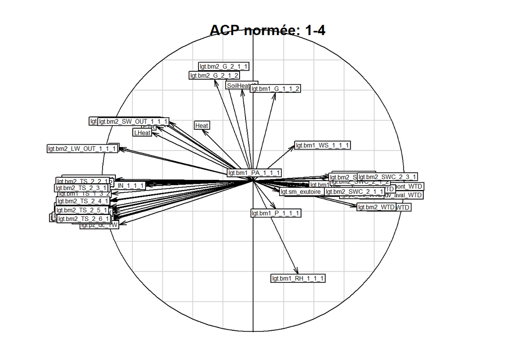

```r
s.corcircle(acpj$co,xax=1,yax=4,clabel = 0.5)#,sub = " cercle de corrélation")
title ( "ACP normée: 1-4")
```

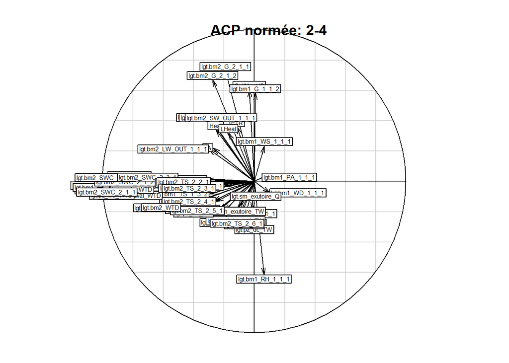

```r
s.corcircle(acpj$co,xax=2,yax=4,clabel = 0.5)#,sub = " cercle de corrélation")
title ( "ACP normée: 2-4")
```

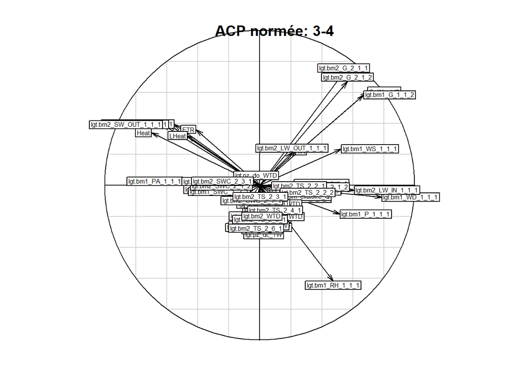

```r
s.corcircle(acpj$co,xax=3,yax=4,clabel = 0.5)#,sub = " cercle de corrélation")
title ( "ACP normée: 3-4")
```